# How Climate-Change Induced Seasonality Impacts Fire Season in Spokane

Claire Generous

3/1/2019

## “Soft knock” Spokane

Spokane is a mid-sized city located in eastern Washington state. While Spokane is not exactly a hub for culture, the city does pride itself on having some of the most beautiful natural landscapes and outdoor activities. Spokane’s weather, relative to the rest of the United States, appears rather temperate. While tornadoes and severe storms ravage other parts of the United States, Spokane experiences these events more similar to a “soft knock” (Loyd and Weiford 2018). However, one outlying weather event in Spokane is fire. Spokane’s wildfire season has become longer, more intense, and less manageable in the past 40 years.

| Wildfire Season | # of unsafe smoke days |
| --- | --- |
| 2018 | 13 |
| 2017 | 16 |
| 2016 | 0 |
| 2015 | 13 |
| 2014 | 1 |
| 2013 | 0 |
| 2012 | 2 |
| 2011 | 0 |
| 2010 | 1 |

The table above is influenced by the Spokane Clean Air Agency shows how since 2010, the number of days of smoke that exceed health-based air quality standards have significantly increased. The trend of fire seasons intensifying is consistent with the surrounding Pacific Northwest (PNW) area. According to the Washington Forest Protection Association, the 2017 Washington fire season had 40 days at the highest level of preparedness (level 5) which was almost three weeks more than during the severe 2015 fire season which was deemed “the most severe fire season in modern history” by the Northwest Interagency Coordination Center (Northwest Interagency Coordination Center 2015). Since the early 1970’s, area burned by fire in the Northwest by nearly 5,000 percent (Westerling 2016). In Washington alone, an estimated 4.1 acres burned from 2000 to 2017, according to the state’s Department of natural Resources (Shinn 2018).

Other research points more directly to how climate change is the driving force behind increased fire seasons. In research published in 2016 in the journal Proceeding of the National Academy of Sciences, University of Idaho associate Geology professor John Abatzoglou and a fellow researcher concluded that anthropogenic increases in temperature and vapor pressure in the atmosphere deficit significantly enhanced fuel aridity (for fires) across western US forests over the past several decades. Between 2000 and 2015, the human-caused increases in temperature and reduced vapor pressure contributed to 75% more forested area experiencing high (>1 σ) fire-season fuel aridity and an average of nine additional days per year of high fire potential (Abatzoglou and Williams 2016, p. 11770).

## Does climate change have to do with fire increases?

The question about the increase in fire season in Spokane is whether increases are related to climate change. To assess how climate change impacts Spokane’s fire season, examining weather patterns in Spokane with the rest of the PNW is informative. Trends that were apparent in R were the seasonal precipitation and temperature patterns. I hypothesize that climate change driven temperature increases and precipitation increases during certain seasons since 1980 contribute to increases in Spokane’s fire season.

## How does precipitation impact fire season ?

According to NOAA’s National Climate Report for 2017, in Washington, from the period 1895-2017 during the Spring months March through May, precipitation was much above average. This trend is supported in Spokane’s data as well.

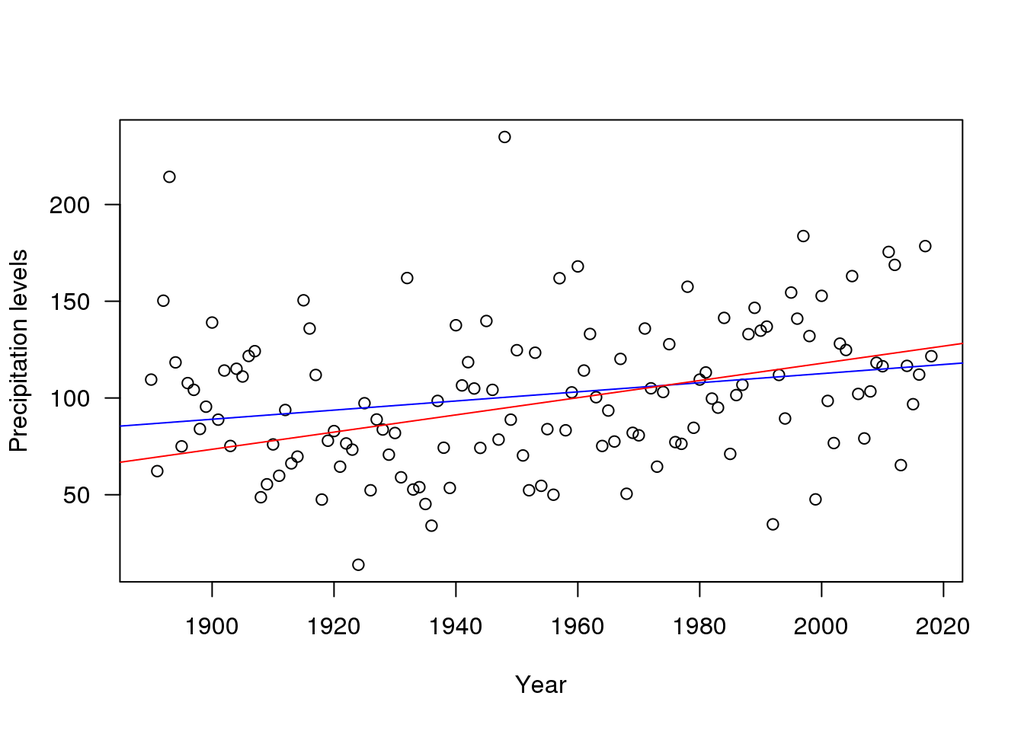

According to the USDA Forest Service and DOI Bureau of Land Management’s 2017 Pacific Northwest Fire Narrative and the National Interagency Coordination Center’s Wildland Fire Summary and Statistics Annual Report for 2017, the increase in precipitation during the winter and spring months results in an increase in fire fuels (more grasses).

## What do higher temperatures have to do with fire season?

Because of the increases in precipitation during the winter and spring months which result in more grass growth, variability in temperatures in summer months are extremely consequential. NOAA’s National Climate Report for 2017 shows that in Washington, from the period 1895-2017 during the Summer months June through August, temperature was much above average. The NOAA report also says that the heat extremes which resulted in destructive fires extended throughout the summer and well into autumn.

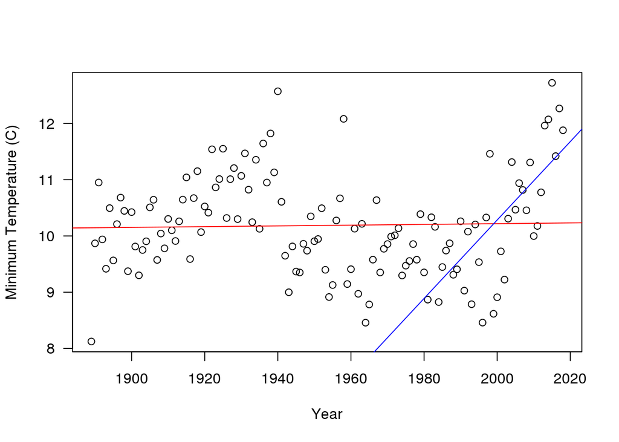

Clearly the warming trend during summer months that has impacted the PNW has also impacted Spokane and thus Spokane’s fire season. The USDA Forest Service and DOI Bureau of Land Management’s 2017 Pacific Northwest Fire Narrative talks about how the rapid change in temperatures in the summer months combined with decreased precipitation after the heavy rainfall during the spring months created a flash drought potential. The high precipitation levels in the winter and spring combined with the warm temperatures in early summer resulted in significant plant growth. Precipitation decreases and temperature increases resulted in high evapotranspiration rates, leading to rapid curing of grasses, rapid loss of moisture from dead woody fuels, and rapid development of drought stress in live fuels such as trees and shrubs” (2017 Pacific Northwest Fire Narrative 2017, p. 6). The dried out climate from rising temperatures contributed to the increase in Spokane and other PNW area’s fire seasons.

## Projected outcomes of increased fires

If these precipitation and temperature trends continue, consequences will be grave. The Seattle Times reported that some studies according to the Climate Impacts Group predict forests will contain less wood, and thus less carbon, as well as vegetation shifts (Berton, 2017). The Department of Ecology in the State of Washington also agrees that as the frequency and intensity of wildfires increases, forestlands and its resources as well as habitats for wildlife will be damaged. The Department of Ecology in the State of Washington also points to social impacts of increased fire seasons, including more unhealthy levels of air quality that create respiratory problems for certain groups and threats to homes, property, and agriculture. A ScienceDirect article also addresses human health impacts of increased fire seasons including thousands of illnesses and premature deaths occurring due to particulates released into the air by fires (Fann N, et al. 2018). An article from the Union of Concerned Scientists says, “due to warmer and drier summer conditions, the typical annual area burned by fire in the Northwest is projected to double by the 2040s and quadruple by the 2080s” (Confronting Climate Change in Washington 2018).

## Looking forward

Although the Pacific Northwest and Spokane may not seem to be as affected by climate change and rising temperatures, these areas must still be given appropriate attention. While the seasonal rises in temperatures and precipitation may not necessarily be solely due to climate change, the impacts are still damning for the PNW and Spokane’s future.

In the early 1900’s, state and federal governments began to aggressively fight wildfires, but this caused denser and more fire-prone forests (Meyer 2017). The Natural Resource Defense Council says that “prematurely putting out small fires that could have cleared away undergrowth leaves some forests clogged with highly flammable small trees and shrubs. Unnecessarily suppressing them can increase the risks of subsequent fires being bigger and harder to control” (Where There’s Fire, There’s Smoke, p. 2, 2013).

Rather than focusing on how to manage fires, more resources should be put into preventing them in the first place. For example, in Oregon, a new Carbon Policy office is considering a “carbon cap and invest” bill similar to California’s Assembly Bill 398. On the Washington State ballot in November 2018, Initiative 1631, also known as the Protect Washington Act, “proposes collecting a pollution-reduction fee from “large emitters, based on the carbon content of fossil fuels and electricity…sold or used within this state” (Shinn 2018). The Washington Department of Natural Resources has developed a 20-Year Forest Health Strategic Plan for easter Washington through increasing forest and watershed resilience and protecting communities, property, ecosystems, assets and working forests.

## Conclusion

Even though weather patterns in Spokane may not be as extreme as other areas, weather patterns that impact Spokane’s fire season still impacts the lives of Spokanites and the natural environment. Spokane is relatively politically conservative and far behind Seattle in forest fire mitigation and prevention, but the weather trends impacting the PNW and Spokane fire season cannot be ignored. By utilizing prevention tactics like the ones described above, Spokane can change the fire season trend before it becomes irreversible.

## Bibliography

Abatzoglou J, Williams A. 2016. Impact of anthropogenic climate change on wildfire across western US forests [Internet]. Proceedings of the National Academy of Sciences. Volume 113: 11770. Available from: https://www.pnas.org/content/113/42/11770

Confronting Climate Change in Washington (2018) [Internet]. 2018. Union of Concerned Scientists; [cited 2019 Mar 1]. Available from: http://www.wfpa.org/news-resources/blog/length-northwest-forest-fire-season-continues-grow/

Fann N, et al., editors. 2018. The health impacts and economic value of wildland fire episodes in the U.S.: 2008-2012. Science of the Total Environment [Internet]. [cited 2019 Mar 1]; Volumes 610-611. Available from: https://www.sciencedirect.com/science/article/pii/S0048969717320223

Franz H, et al., editors. 2017. 20-Year Forest Health Strategic Plan [Internet]. Washington State Dept of Natural Resources; [cited 2019 Mar 1]. Available from: https://www.dnr.wa.gov/publications/rp_forest_health_20_year_strategic_plan.pdf?g0e0fe

Length of Northwest Forest Fire Season Continues to Grow [Internet]. 2018. Washington Forest Protection Association; [cited 2019 Mar 1]. Available from: http://www.wfpa.org/news-resources/blog/length-northwest-forest-fire-season-continues-grow/

Loyd N. 2018. Weathercatch: Severe weather events — there’s something about May [Internet]. Washington State University: WSU Insider; [cited 2019 Mar 1]. Available from: https://news.wsu.edu/2018/05/16/theres-something-about-may/

Meyer R. 2017. Has Climate Change Intensified 2017’s Western Wildfires? [Internet]. The Atlantic: Science; [cited 2019 Mar 1]. Available from: https://www.theatlantic.com/science/archive/2017/09/why-is-2017-so-bad-for-wildfires-climate-change/539130/

National Climate Report for Annual 2017 [Internet]. 2018. NOAA National Centers for Environmental Information: State of the Climate; [cited 2019 Mar 1]. Available from: https://www.ncdc.noaa.gov/sotc/national/201713

Northwest Interagency Coordination Center [Internet]. 2015. National Geographic Area Coordination Center; [cited 2019 Mar 1]. Available from: https://gacc.nifc.gov/nwcc/

Shinn L. 2018. In the Pacific Northwest, Testing Out New WIldfire Defenses on the Front Lines [Internet]. Natural Resources Defense Council; [cited 2019 Mar 1]. Available from: https://www.nrdc.org/stories/pacific-northwest-testing-out-new-wildfire-defenses-front-lines

Westerling A. 2016. Wildfires in West have gotten bigger, more frequent and longer since the 1980s [Internet]. The Conversation; [cited 2019 Mar 1]. Available from: https://theconversation.com/wildfires-in-west-have-gotten-bigger-more-frequent-and-longer-since-the-1980s-42993

Wildfire Smoke [Internet]. [date unknown]. Spokane Regional Clean Air Agency; [cited 2019 Mar 1]. Available from: https://www.spokanecleanair.org/wildfire-smoke

Wildfires, air quality & climate change [Internet]. [date unknown]. Department of Ecology State of Washington; [cited 2019 Mar 1]. Available from: https://ecology.wa.gov/Air-Climate/Climate-change/About-climate-change/Wildfire-risks

2013. Where There’s Fire, There’s Smoke: Wildfire Smoke Affects Communities Distant from Deadly Flames [Internet]. Natural Resources Defense Council; [cited 2019 Mar 1]. Available from: https://www.nrdc.org/sites/default/files/wildfire-smoke-IB.pdf
2014. Wildland Fire Summary and Statistics Annual Report 2017 [Internet]. Predictive Services; National Interagency Coordination Center. [cited 2019 Mar 1]. Available from: https://www.predictiveservices.nifc.gov/intelligence/2017_statssumm/annual_report_2017.pdf
2015. 2017 Pacific Northwest Fire Narrative [Internet]. USDA Forest Service and DOI Bureau of Land Management. [cited 2019 Mar 1]. Available from: https://www.fs.usda.gov/Internet/FSE_DOCUMENTS/fseprd572804.pdf